# Analiza svjetlosnog onečišćenja sjeverne Hrvatske

# Sadržaj

1. Sažetak
2. Uvod
3. Ciljevi
4. O podacima

## Sažetak

Ovaj projekt istražuje dinamiku svjetlosnog onečišćenja na području sjeverne Hrvatske koristeći satelitske podatke projekta NASA Black Marble. Rad obuhvaća vremensku analizu promjena intenziteta svjetlosti te detaljan prostorni prikaz stanja na razini regije i pojedinih urbanih središta sjeverne Hrvatske. Statističkom obradom utvrđeni su trendovi rasta ili pada emisija te su identificirane kritične točke.

## Uvod

Svjetlosno onečišćenje postaje jedan od najbrže rastućih ekoloških problema modernog doba, utječući na zdravlje ljudi, bioraznolikost, energetsku učinkovitost, ali i na astronomska opažanja. Fenomen svjetlosnog onečišćenja opisuje se kao promjene razine osvijetljenosti koja se emitira putem umjetnih izvora svjetlosti. Prema istraživanjima, noćno nebo svake godine postaje prosječno 10% sjajnije u odnosu na prethodnu godinu. Tijekom narednih 20tak godina, očekuje se da će noćno nebo biti svjetlije četiri puta. [https://www.nhm.ac.uk/discover/news/2023/january/increasing-light-pollution-drowning-out-stars.html]

Sjeverna Hrvatska predstavlja specifičan poligon za proučavanje ovog fenomena. Zahvaljujući naprednim senzorima poput VIIRS-a, danas možemo precizno mjeriti umjetno zračenje iz svemira. Ovaj rad koristi te podatke kako bi kvantificirao promjene u osvjetljenju koje su se dogodile u posljednjih nekoliko godina uslijed urbanizacije i modernizacije infrastrukture.

## Ciljevi

1. Analiza vremenskih trendova: utvrditi kretanje intenziteta svjetlosnog onečišćenja u sjevernoj Hrvatskoj kroz višegodišnje razdoblje
2. Regionalna usporedba: identificirati razlike u razinama onečišćenja između različitih dijelova regije (npr. Međimurje, Zagorje, Podravina).
3. Urbana mikro-analiza: provesti usporedbu specifičnih gradova kako bi se odredilo koji centri imaju najveći doprinos ukupnom sjevernom "sjaju".

# O podacima

NASA Black Marble je skupina znanstvenih podataka koji prikazuju Zemlju noću u visokoj rezoluciji (500m), koristeći VIIRS instrument na satelitima Suomi NPP, NOAA-20 i NOAA-21 za praćenje ljudskih aktivnosti i prirodnih promjena od 2012. godine. Podaci su atmosferski ispravljeni za uklanjanje mjesečine i snijega, omogućujući analizu urbanizacije, infrastrukture, prirodnih katastrofa i svjetlosnog onečišćenja.

Slijedeća slika prikazuje proces kalibracije podataka za NASA-in projekt "Black Marble", odnosno kako se od sirovog satelitskog signala dolazi do čiste slike noćnih svjetala Zemlje.

- Satelitski senzor (VIIRS): prima ukupno zračenje s površine, ali i "šum" iz drugih izvora.
- Izvori smetnji: senzor mora prepoznati i ukloniti utjecaj mjesečine, svjetlucanja atmosfere i raspršene sunčeve svjetlosti
- Atmosferska korekcija: uklanjaju se efekti oblaka, vlage i čestica u zraku kako bi se vidjela stvarna površina
- BRDF korekcija: ispravljaju se razlike u refleksiji ovisno o kutu gledanja, godišnjem dobu ili prisutnosti snijega
- Konačni rezultat: nakon svih ovih filtera dobivaju se precizni podaci o ljudskoj aktivnosti i umjetnoj rasvjeti na tlu

[figure not shown]

Slika 1: Shematski prikaz obrade NASA Black Marble podataka

Izvor: https://blackmarble.gsfc.nasa.gov/

# Dohvat podataka i biblioteka

Za dohvat podataka putem BlackMarble sučelja potrebno je definirati geografski okvir koji određuje područje interesa. U tu svrhu koristi se datoteka *north_croatia.json*, koja sadrži prostorni opis sjeverne Hrvatske u obliku geografskih poligona sadržanih unutar GeoJSON datoteke.

[figure not shown]

Podaci se s BlackMarble sučelja dohvaćaju standardiziranim API metodama. Sučelje na temelju proslijeđenog geografskog poligona automatski generira i vraća rasterske zapise koji sadrže tražene informacije za odabrano područje.

Jednom dohvaćeni podaci pohranjuju se u trajnu memoriju, čime se omogućuje njihovo ponovno korištenje bez potrebe za ponovnim pristupom BlackMarble sučelju.

Podaci sadrže sljedeće varijable:

- **time** – vremenska komponenta podataka, izražena u godinama ili mjesecima
- **y** – prostorna varijabla koja predstavlja geografsku širinu (latitudu) piksela
- **x** – prostorna varijabla koja predstavlja geografsku dužinu (longitudu) piksela
- **NearNadir_Composite_Snow_Free** – vrijednost radijance izražena u nW/cm²sr

|  | time | y | x | NearNadir_Composite_Snow_Free |
| --- | --- | --- | --- | --- |
| 0 | 2012-01-01 | 46.548039 | 15.593872 | NaN |
| 1 | 2012-01-01 | 46.548039 | 15.598039 | NaN |
| 2 | 2012-01-01 | 46.548039 | 15.602205 | NaN |
| 3 | 2012-01-01 | 46.548039 | 15.606372 | NaN |
| 4 | 2012-01-01 | 46.548039 | 15.610539 | NaN |
| ... | ... | ... | ... | ... |
| 856955 | 2024-01-01 | 45.885539 | 17.289705 | NaN |
| 856956 | 2024-01-01 | 45.885539 | 17.293872 | NaN |
| 856957 | 2024-01-01 | 45.885539 | 17.298039 | NaN |
| 856958 | 2024-01-01 | 45.885539 | 17.302205 | NaN |
| 856959 | 2024-01-01 | 45.885539 | 17.306372 | NaN |

856960 rows × 4 columns

# Distribucija podataka

Distribucija podataka pokazuje kako su vrijednosti raspoređene unutar skupa. Ova analiza pomaže razumjeti **raspon, koncentraciju i rijetke ekstremne vrijednosti** u skupu podataka prije daljnjih statističkih metoda i vizualizacija.

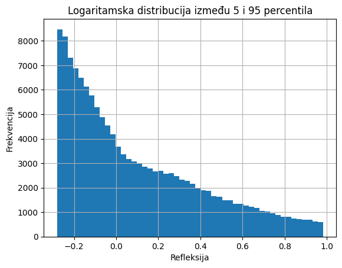

Ako se iz razmatranja izuzme gornje i donje ekstreme te uzmu vrijednosti između 5-tog i 95-tog kvartila, odnosno 90% vrijednosti, dobiva se jasnija slika o distribuciji podataka te se dolazi do konačnog zaključka:

Distribucija je **desno asimetrična** jer većina područja ima nisku razinu svjetlosnog onečišćenja dok manji broj urbanih područja značajno odstupa prema većim vrijednostima što je u skladu s očekivanim obrascem kod noćnih satelitskih podataka gdje su visoke vrijednosti rijetke, a niske prevladavaju.

## Trend kretanja podataka

Analiza trendova pokazuje kako se vrijednosti podataka mijenjaju kroz vrijeme, što omogućuje uvid u promjene razine svjetlosnog onečišćenja tijekom promatranog perioda.

Prosječna radijanca kroz vrijeme pokazuje **opći porast radijance**, što ukazuje na povećanje svjetlosnog onečišćenja u sjevernoj Hrvatskoj, uz povremene manje padove u nekim periodima.

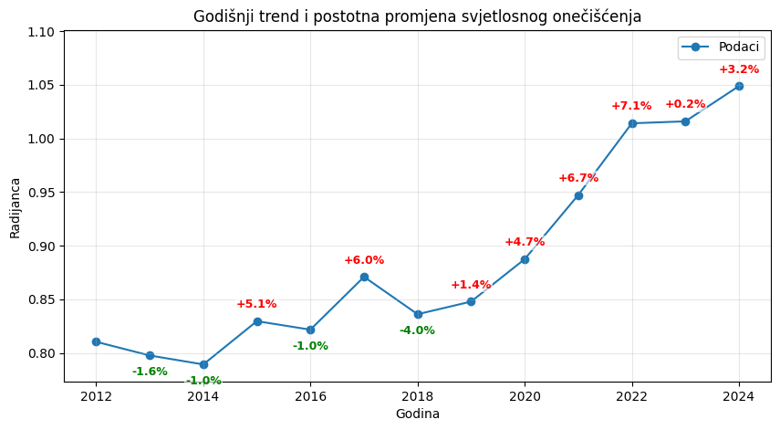

Vidljivo je da su najznačajniji trendovi rasta radijance zabilježeni u periodu od 2019. do 2022. godine.  
Iako bi se tijekom 2020. godine, uslijed smanjenog ljudskog kretanja i aktivnosti zbog pandemije COVID-19, očekivao pad svjetlosnog onečišćenja, prosječne vrijednosti ipak pokazuju blagi rast, što može biti posljedica intenziviranja urbanih aktivnosti i trajnog povećanja svjetlosnog opterećenja u gradskim područjima.

# Bortle skala

Bortleova skala je sustav od devet razina koji se koristi za mjerenje tame noćnog neba i utjecaja svjetlosnog onečišćenja na određenoj lokaciji. Govori koliko je nebo "čisto" i što točno možemo vidjeti golim okom ili teleskopom:

- Klasa 1: savršeno tamno nebo. Noćno nebo puno je detalja koji su u gradovima gotovo nevidljivi, vidljiva je i sama Mliječna staza
- Klase 2–4: ruralno i seosko nebo. Odlična vidljivost s minimalnim utjecajem udaljenih gradova. Mliječna staza je jasno vidljiva s puno strukture
- Klase 5–7: predgrađa. Nebo je sivkasto ili žućkasto zbog ulične rasvjete. Mliječna staza je jedva vidljiva ili se vidi samo u zenitu (iznad glave)
- Klase 8–9: gradsko nebo. Vidljive su samo najsjajnije zvijezde i planeti. Nebo je toliko svijetlo da zviježđa postaju nevidljiva

Kako bi se dobili podaci za Bortleovu skalu, radijanca se mora pretvoriti u tzv. SQM (sky quality meter) jedinice - magnitudu površkinskog sjaja neba. Satelit mjeri radijancu (svjetlo koje ide s tla u nebo), ali astronomi koriste SQM (jedinicu za tamu neba koja se vidi s tla). Što je SQM broj veći, to je nebo tamnije. Za pretvaranje se koristi sljedeća formula:

$$SQM = 21.3 - 2.303 \cdot \log_{10}(radijanca)$$

- $SQM$: Magnituda površinskog sjaja neba ($mag/arcsec^2$). Veći broj = tamnije nebo.
- $21.3$: Referentna konstanta (vrijednost za potpuno tamno nebo).
- $2.303$: Faktor konverzije iz baze prirodnog logaritma u dekadski (povezuje fizikalnu energiju s astronomskim magnitudama).
- $radijanca$: Intenzitet svjetla koji satelit mjeri s neba ($nW/cm^2/sr$).

Izvor formule: Indoor calibration of Sky Quality Meters: Linearity, spectral responsivity and uncertainty analysis (2016, Journal of Quantitative Spectroscopy and Radiative Transfer) - (https://www.sciencedirect.com/science/article/pii/S0022407315302077)

## Mjesečna analiza

Nakon godišnjih analiza, slijede mjesečne. Analizirat će se mjesečni podaci od siječnja 2023. do prosinca 2025. godine. Svaka godina spremljena je u zasebnu datoteku s toga ih je potrebno spojiti u jedinstvenu.

|  | time | y | x | NearNadir_Composite_Snow_Free |
| --- | --- | --- | --- | --- |
| 0 | 2023-01-01 | 46.548039 | 15.593872 | NaN |
| 1 | 2023-01-01 | 46.548039 | 15.598039 | NaN |
| 2 | 2023-01-01 | 46.548039 | 15.602205 | NaN |
| 3 | 2023-01-01 | 46.548039 | 15.606372 | NaN |
| 4 | 2023-01-01 | 46.548039 | 15.610539 | NaN |

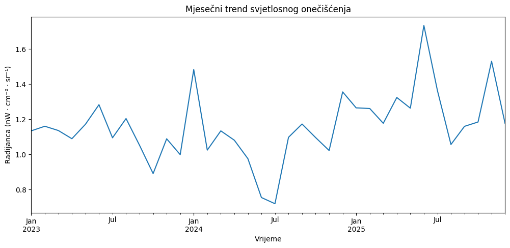

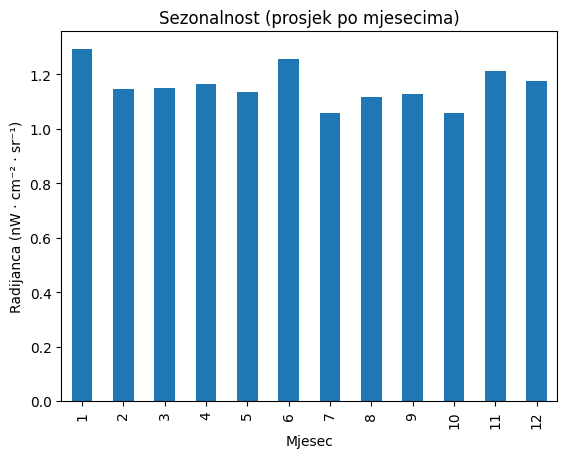

## Varaždin

**Napomena!** Na grafovima koji slijede, puna linija označava srednju vrijednost (prosjek) mjerenja radijance u promatranom razdoblju. Osjenčano područje oko linije predstavlja 95-postotni interval pouzdanosti, koji vizualizira razinu varijabilnosti podataka. Širina tog područja ukazuje na raspršenost mjerenja: šire osjenčanje sugerira veća odstupanja pojedinačnih očitanja od prosjeka, dok uže područje potvrđuje veću ujednačenost i stabilnost podataka

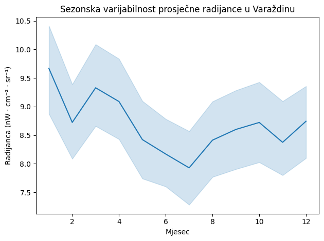

Rezultati potvrđuju hipotezu o povećanom intenzitetu radijance tijekom zimskih mjeseci, što korelira s duljim radom umjetne rasvjete zbog dužih noći i manjkom vegetacijskog pokrova koji bi blokirao izravnu emisiju svjetlosti prema satelitu. Suprotno tome, ljetni minimum ukazuje na utjecaj kraćih noći i prisutnosti vegetacije na smanjenje izmjerenih vrijednosti.

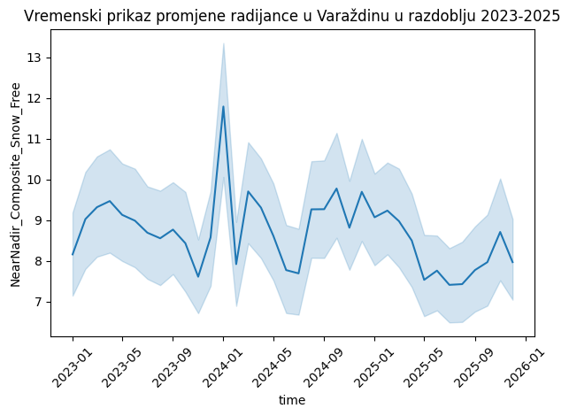

Graf potvrđuje ponavljajući ciklus vidljiv na prethodnom prikazu, gdje svaka godina ima brijeg tijekom zimskih mjeseci i dolinu tijekom ljetnih. Siječanj 2024. godine predstavlja neuobičajeno visok ekstrem koji može ukazivati na specifične atmosferske uvjete ili pojačanu rasvjetu te godine

## Čakovec

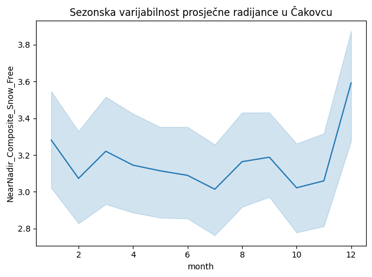

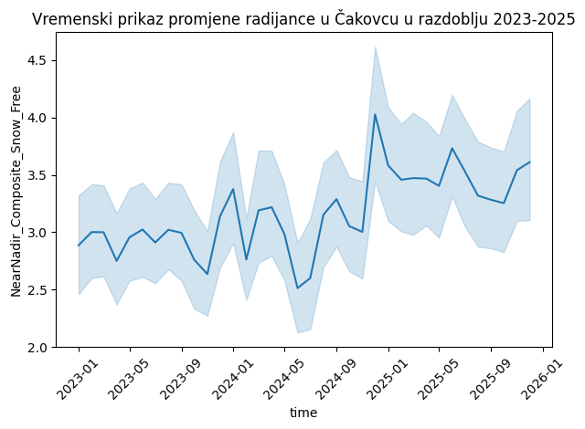

Analiza podataka za Čakovec ukazuje na jasnu sezonsku dinamiku s najnižim vrijednostima radijance u srpnju te izrazitim vrhuncem u prosincu. Dok sezonski grafikon potvrđuje utjecaj godišnjih doba na vidljivost izvora svjetlosti, vremenski niz (2023. – 2025.) otkriva postupan uzlazni trend ukupnog svjetlosnog onečišćenja. Posebno se ističe kraj 2024. godine s ekstremnim vrijednostima koje znatno nadmašuju početak promatranog razdoblja, što sugerira povećanje intenziteta ili obuhvata umjetne rasvjete u gradu kroz vrijeme.

## Koprivnica

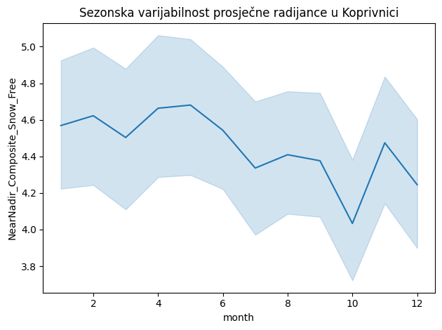

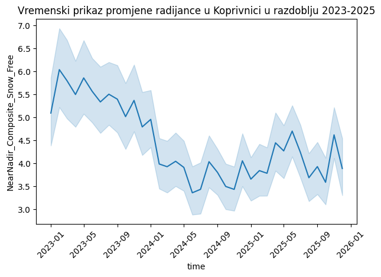

## Krapina

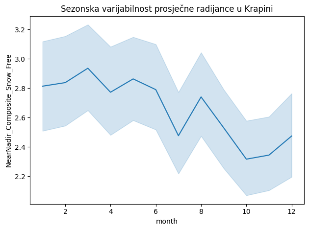

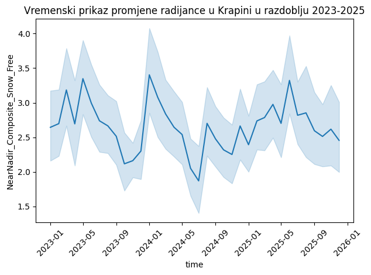